# How effectively can LSTM networks predict impending software-system failures from multivariate telemetry

This is the capstone project of IDC6910 class

Author

Duc Nguyen, Luis Madrigal (Advisor: Dr. Cohen)

Published

November 3, 2026

Slides: slides.html ( Go to `slides.qmd` to edit)

## Introduction

Modern software systems generate large amounts of telemetry data, including performance metrics, logs, and other operational signals. This information may contain early warning signs of system failures; however, detecting those signs can be challenging, especially in complex systems. Improving failure prediction can help organizations respond earlier, reduce system downtime and associated costs, and improve overall system reliability.

This project will use Microsoft’s OpenRCA dataset (Xu et al. 2025a) to investigate whether Long Short-Term Memory (LSTM) neural networks can predict impending software-system failures from system telemetry. Because LSTMs are designed to learn patterns over time, they may be useful for detecting changes in telemetry data that occur before a system failure. We will evaluate how accurately failures can be predicted at different time horizons and whether combining multiple telemetry sources improves prediction performance compared with using a single source. Overall, this project applies machine learning to a practical software reliability problem by testing the effectiveness of telemetry data for early failure detection.

Previous research is supportive of using LSTM models in the analysis of sequential data. (Gonzalez and Yu 2018) showed that LSTM networks can be used in modeling nonlinear systems, while (Ergen and Kozat 2020) used LSTM-based methods for anomaly detection in data sequences with variable length. Other studies applied LSTMs to telemetry data obtained from computer systems. (Mudgal and Wouhaybi 2024) used a combined LSTM encoder in anomaly detection methods. These include Isolation Forest, used to identify PC system failures from CPU, memory, disk, temperature, and system data. This study obtained results that suggested LSTM-based telemetry analysis can provide useful results for system-failure detection.

System log research also shows how important sequential modeling can be in failure-related tasks. (Chen, Luktarhan, and Lv 2022) used two LSTM networks in the analysis of events before and after a log entry; this improved anomaly detection in long log sequences. In addition, (Hadadi et al. 2024) researched deep learning for log-based failure prediction and found that model performance is dependent on how log data are represented and transformed into sequences. The OpenRCA dataset will be particularly useful in this project as it contains real failure case data from enterprise systems, with multiple sources of telemetry, such as logs, metrics, and traces (Xu et al. 2025b). While the prior work mentioned mainly focused on anomaly detection or cause analysis, this project will be more focused on predicting failures before they occur and testing the efficacy of multiple telemetry sources in improving early failure prediction performance.

## Methods

A Long Short-Term Memory (LSTM) network is a type of recurrent neural network (RNN) designed to learn from sequential data while retaining useful information over time. As it processes each time step, the LSTM updates a cell state that carries information forward. Three gates control this process: the forget gate determines what information to retain, the input gate determines what new information to add, and the output gate determines what information to expose to the next time step. This gating structure helps the network learn which patterns of change over time are useful for making predictions (Hochreiter and Schmidhuber 1997).

We chose an LSTM because it can learn from the order of telemetry measurements over time. Some faults may be preceded by gradual changes in metrics, such as increasing memory use or CPU utilization that remains elevated. By processing a recent sequence of measurements, the model can learn whether these patterns help predict a fault before it begins. This section explains how the LSTM processes sequences, the assumptions behind our modeling approach, how we prepare OpenRCA telemetry for the model, and how we train it.

### Recurrent Neural Networks and the Vanishing Gradient

A recurrent neural network processes a sequence $x_1, x_2, \dots, x_T$ one step at a time. At each step it combines the current input $x_t$ with a *hidden state* $h_{t-1}$ that summarizes everything it has seen so far:

$$h_t = \tanh\left(W x_t + U h_{t-1} + b\right)
\tag{1}$$

The same weights $W$, $U$ and $b$ are reused at every time step, so the network can handle a sequence of any length with a fixed number of parameters.

RNNs are trained with *backpropagation through time* (BPTT) (Werbos 1990): the network is “unrolled” over the sequence, and the error at the final step is passed backwards through every earlier step. The gradient that reaches step $t-k$ contains a product of $k$ Jacobian matrices,

$$\frac{\partial h_t}{\partial h_{t-k}} = \prod_{j=t-k+1}^{t} \operatorname{diag}\!\left(1 - h_j^2\right) U .
\tag{2}$$

When the terms in this product are smaller than one, the gradient shrinks exponentially as $k$ grows (it *vanishes*); when they are larger than one, it grows exponentially (it *explodes*) (Bengio, Simard, and Frasconi 1994; Pascanu, Mikolov, and Bengio 2013). In practice, a plain RNN therefore learns only short-range patterns. For our problem, this is a serious limitation: an early warning sign 20 minutes before a fault is 20 steps back in the sequence.

### Mathematical Foundations of the LSTM

The LSTM replaces the single update in Equation 1 with a memory cell $c_t$ and three gates. Following the standard formulation with a forget gate (Gers, Schmidhuber, and Cummins 2000), the computation at each time step $t$ is:

$$\begin{aligned}
f_t &= \sigma\left(W_f x_t + U_f h_{t-1} + b_f\right) && \text{forget gate}\\
i_t &= \sigma\left(W_i x_t + U_i h_{t-1} + b_i\right) && \text{input gate}\\
o_t &= \sigma\left(W_o x_t + U_o h_{t-1} + b_o\right) && \text{output gate}\\
\tilde{c}_t &= \tanh\left(W_c x_t + U_c h_{t-1} + b_c\right) && \text{candidate memory}\\
c_t &= f_t \odot c_{t-1} + i_t \odot \tilde{c}_t && \text{cell state update}\\
h_t &= o_t \odot \tanh\left(c_t\right) && \text{hidden state (output)}
\end{aligned}
\tag{3}$$

where:

- $x_t$ is the input vector at time $t$: the telemetry readings for one minute.
- $h_{t-1}$ is the hidden state from the previous minute; $h_t$ is the new one.
- $c_{t-1}$ and $c_t$ are the old and new **cell states**: the long-term memory.
- $f_t$, $i_t$, $o_t$ are the **gates**. Each is a vector of numbers between 0 and 1 produced by the logistic sigmoid $\sigma(z) = 1/(1+e^{-z})$. A value near 0 means “block” and a value near 1 means “let through”.
- $\tilde{c}_t$ is the **candidate memory**: new information that could be written to the cell. The $\tanh$ function keeps it between $-1$ and $1$.
- $W_\ast$ are the input weight matrices, $U_\ast$ are the recurrent weight matrices, and $b_\ast$ are bias vectors, one set for each gate and the candidate.
- $\odot$ is element-wise (Hadamard) multiplication.

**What each gate does.**

- The **forget gate** $f_t$ decides how much of the old memory $c_{t-1}$ to keep. If a component of $f_t$ is close to 1, that part of the memory is carried forward; close to 0, it is erased.
- The **input gate** $i_t$ decides how much of the candidate $\tilde{c}_t$ is written into memory. This lets the network ignore minutes that carry no useful information.
- The **output gate** $o_t$ decides how much of the memory is exposed in the hidden state $h_t$, which is what the next step, and eventually the prediction layer, sees.

**Why this fixes the vanishing gradient.** The key line in Equation 3 is the cell update $c_t = f_t \odot c_{t-1} + i_t \odot \tilde{c}_t$. It is *additive*, not a repeated squashing like Equation 1. Along this path, the gradient from one step to the previous is

$$\frac{\partial c_t}{\partial c_{t-1}} \approx \operatorname{diag}(f_t),$$

so as long as the network learns to keep the forget gate open ($f_t \approx 1$), the error signal can travel back across many time steps without shrinking. This is the “constant error carousel” that gives the LSTM its long memory (Hochreiter and Schmidhuber 1997).

#### Matrix and Vector Dimensions

Let $k$ be the number of input features and $d$ the number of hidden units. Then:

| Symbol | Dimension | Meaning |
| --- | --- | --- |
| $x_t$ | $k \times 1$ | telemetry at minute $t$ |
| $h_t,\; c_t,\; f_t,\; i_t,\; o_t,\; \tilde{c}_t$ | $d \times 1$ | hidden state, cell state, gates, candidate |
| $W_f, W_i, W_o, W_c$ | $d \times k$ | input weights |
| $U_f, U_i, U_o, U_c$ | $d \times d$ | recurrent weights |
| $b_f, b_i, b_o, b_c$ | $d \times 1$ | biases |

The four weight sets are usually stacked into one matrix, so a single LSTM layer has

$$4\left(dk + d^2 + d\right)$$

trainable parameters. In this project, the input has $k = 128$ selected telemetry features and the LSTM has $d = 64$ hidden units, which gives $4(64 \cdot 128 + 64^2 + 64) = 49{,}408$ parameters in the LSTM layer. (PyTorch keeps two bias vectors per gate, which adds another $4d = 256$.) The prediction layer described below adds $d + 1 = 65$ more, for a total of $49{,}729$ parameters. Importantly, this number does not depend on the length of the sequence: the same weights are applied at every minute.

#### Example

To make Equation 3 concrete, consider a toy LSTM with $d = 1$ hidden unit that watches $k = 2$ scaled telemetry features of one container: CPU usage and memory usage. At the previous minute, the network’s state was $h_{t-1} = 0.2$ and $c_{t-1} = 0.5$. At the current minute, CPU usage spikes while memory is normal:

$$x_t = \begin{bmatrix} \text{CPU} \\ \text{Memory} \end{bmatrix}
= \begin{bmatrix} 1.5 \\ 0.3 \end{bmatrix}$$

Suppose training has produced the following weights:

| Gate | $W_\ast$ (CPU, Memory) | $U_\ast$ | $b_\ast$ |
| --- | --- | --- | --- |
| forget $f$ | $[\,0.6,\; -0.2\,]$ | 0.5 | 1.0 |
| input $i$ | $[\,0.8,\; 0.1\,]$ | 0.3 | 0.0 |
| output $o$ | $[\,0.4,\; 0.2\,]$ | 0.6 | 0.2 |
| candidate $\tilde{c}$ | $[\,0.9,\; 0.3\,]$ | 0.4 | $-0.1$ |

**Step 1: gates.** For the forget gate,

$$f_t = \sigma(0.6 \cdot 1.5 - 0.2 \cdot 0.3 + 0.5 \cdot 0.2 + 1.0) = \sigma(1.94) = 0.874 .$$

The other gates follow in the same way:

$$i_t = \sigma(1.29) = 0.784, \qquad
o_t = \sigma(0.98) = 0.727, \qquad
\tilde{c}_t = \tanh(1.42) = 0.890 .$$

**Step 2: update the memory.**

$$c_t = \underbrace{0.874 \times 0.5}_{\text{kept from before}}
+ \underbrace{0.784 \times 0.890}_{\text{newly written}}
= 0.437 + 0.698 = 1.135$$

**Step 3: produce the output.**

$$h_t = 0.727 \times \tanh(1.135) = 0.727 \times 0.813 = 0.591$$

The network kept most of its earlier memory (87 %) and added a large new contribution because the CPU spike opened the input gate. The value of $c_t$ has grown from 0.5 to 1.135, so the “something unusual is happening” signal will be carried into the next minutes. Repeating these three steps for every minute of the look-back window is all the LSTM does; training consists of finding weights that make this memory useful for predicting failures.

#### From a Sequence to a Failure Prediction

For each minute $t$ we give the LSTM the previous $L = 60$ minutes of telemetry, $x_{t-59}, \dots, x_t$, and run Equation 3 over them in order. Only the final hidden state $h_t$ is used for the prediction, because by then it summarizes the whole window. It passes through dropout and a single linear layer, and a sigmoid turns the result into a probability:

$$\hat{p}_t = \sigma\!\left(v^{\top} \operatorname{Dropout}(h_t) + b_v\right),
\tag{4}$$

where $v$ is a $d \times 1$ weight vector and $b_v$ is a scalar. $\hat{p}_t$ is the model’s estimated probability that a failure will start within the next $H$ minutes.

[figure not shown]

Figure 1: The LSTM unrolled over a 60-minute look-back window. The same cell (same weights) is applied every minute; only the final hidden state feeds the prediction.

### Parameter Estimation

The parameters $\theta = \{W_\ast, U_\ast, b_\ast, v, b_v\}$ are learned by minimizing a **weighted binary cross-entropy** loss over the $N$ training windows:

$$\mathcal{L}(\theta) = -\frac{1}{N}\sum_{n=1}^{N}
\Big[\, w_{+}\, y_n \log \hat{p}_n + (1 - y_n)\log\left(1 - \hat{p}_n\right) \Big]
\tag{5}$$

where $y_n \in \{0, 1\}$ is the true label. Failures are rare, so the positive-class weight $w_{+}$ is set to the ratio of negative to positive windows in the training data. Without this weight the model could reach a low loss by always predicting “no failure”.

Gradients of Equation 5 are computed by backpropagation through time and the weights are updated with the **Adam** optimizer (Kingma and Ba 2015), which adapts the step size for each parameter. Several standard techniques keep training stable and reduce overfitting:

- **Gradient clipping.** If the overall gradient norm exceeds 5 it is rescaled to 5. This guards against the exploding-gradient problem described above (Pascanu, Mikolov, and Bengio 2013).
- **Dropout** with rate 0.2 on the final hidden state randomly zeroes units during training, so the prediction cannot rely on any single unit (Srivastava et al. 2014).
- **Weight decay** of $10^{-5}$ adds a small L2 penalty on the weights.
- **Early stopping.** After each epoch the model is scored on a separate validation set. Training stops when the validation score has not improved for 4 epochs, and the weights from the best epoch are restored.

Table 1: Default LSTM configuration.

| Setting | Value |
| --- | --- |
| Look-back window $L$ | 60 minutes |
| Input features $k$ | 128 |
| Hidden units $d$ | 64 |
| LSTM layers | 1 |
| Dropout | 0.2 |
| Optimizer | Adam, learning rate $10^{-3}$, weight decay $10^{-5}$ |
| Batch size | 128 |
| Maximum epochs | 15 |
| Early-stopping patience | 4 epochs (on validation PR-AUC) |
| Gradient clipping | max norm 5 |

## Analysis and Results

### Dataset Description

The data come from **OpenRCA** (Xu et al. 2025a), a public benchmark released by Microsoft for root-cause analysis of software failures. OpenRCA collects telemetry from three enterprise microservice systems: **Bank**, **Telecom** and **Market** (the last split into two deployments, `cloudbed-1` and `cloudbed-2`), into which engineers deliberately injected faults such as CPU exhaustion, memory leaks and network delays. For every system, OpenRCA provides:

- **Telemetry**, organised into one folder per day, with three modalities:
  - **metrics**: numeric key performance indicators (KPIs) such as CPU use, memory use, response time, and request counts, sampled every few seconds to minutes;
  - **logs**: text messages written by the services;
  - **traces**: records of individual requests travelling between services.
- **A fault record** (`record.csv`) listing every injected fault with its start time, the component it was injected into, and the type of fault.

**Scope of this study.** We focus on the **Bank** and **Telecom** systems and on their **metric** telemetry only. We chose these two systems because:

1. Each is a single, self-contained system with one fault record, so the telemetry and the labels line up directly. Market is split into two separate deployments that would each need their own pipeline.
2. They are very different from each other (different business domains, numbers of components, monitoring tools and time periods), so a result that holds on both is more convincing than a result on one.
3. Metrics are numeric time series that can be placed on a common one-minute grid, which is the input the LSTM needs. Logs and traces would first require text parsing and request-level aggregation, which is outside the scope of this project.

Table 2: Overview of the two OpenRCA systems used in this study.

|  | **Bank** | **Telecom** |
| --- | --- | --- |
| Domain | Online banking platform | Telecom operator services |
| Recorded days | 10 (2021-03-04 to 2021-03-25, not consecutive) | 15 (2020-04-11 to 2020-05-31, not consecutive) |
| Telemetry per day | 24 hours (1,440 minutes) | 6 hours, 00:00–05:59 (360 minutes) |
| Total minutes | 14,400 | 5,400 |
| Metric files per day | `metric_container.csv`, `metric_app.csv` | `metric_node.csv`, `metric_container.csv`, `metric_middleware.csv`, `metric_service.csv`, `metric_app.csv` |
| Timestamp unit | seconds | milliseconds |
| Injected faults | 136 | 51 |
| Fault types | 8 | 5 |

All OpenRCA timestamps are Unix epoch values, and all dates and day-folder names are in **UTC+8** (China Standard Time). Dates and times in this report are shown in UTC+8.

#### Variable Description

The **fault record** has the same columns in both systems:

Table 3: Columns of `record.csv`.

| Variable | Description |
| --- | --- |
| `level` | Level of the system where the fault was injected: `pod` (a container), `node` (a host machine) or `service`. All Bank faults are at pod level. |
| `component` | Name of the component the fault was injected into, for example `Mysql02` (Bank) or `docker_003` (Telecom). |
| `timestamp` | Fault start time as a Unix epoch value (seconds). |
| `datetime` | The same start time written as a date and time in UTC+8. |
| `reason` | Type of fault, for example `high CPU usage` or `network delay`. |

The record gives each fault’s **start time only**; it does not say how long the fault lasted. This is important for labeling, described below.

The **metric files** come in two layouts:

Table 4: Layouts of the metric files.

| Layout | Files | Columns | Meaning |
| --- | --- | --- | --- |
| Long (one row per reading) | Bank `metric_container.csv`; all Telecom files except `metric_app.csv` | `timestamp`, `cmdb_id`, `kpi_name` / `name`, `value` | At time `timestamp`, KPI `kpi_name` on component `cmdb_id` had value `value`. |
| Wide (one row per service per time) | Bank and Telecom `metric_app.csv` | Bank: `timestamp`, `tc`, `rr`, `sr`, `cnt`, `mrt`; Telecom: `startTime`, `serviceName`, `avg_time`, `num`, `succee_num`, `succee_rate` | Application-level request statistics: request count, success rate and mean response time per service. |

Each combination of a component and a KPI, for example `Tomcat04 ‖ CPU utilisation`, is one **time series**, and becomes one input feature for the model.

### Packages

The analysis uses two languages. Python prepares the telemetry and trains the model, because the data are large and the LSTM is built with PyTorch. R reads the saved results and produces the tables and figures in this report.

**Python**

- **pandas** and **pyarrow**: read the metric CSV files, pivot them into minute-by-feature tables and store them as Parquet files.
- **NumPy**: cleaning, scaling, windowing and the evaluation metrics (PR-AUC, ROC-AUC, bootstrap intervals).
- **PyTorch** (Paszke et al. 2019): defines the LSTM, computes gradients by backpropagation through time and trains the model with Adam.

**R**

- **tidyverse** (readr, dplyr, tidyr, purrr, stringr, ggplot2): read the results, reshape them and draw the figures.
- **knitr**: format tables.
- **scales**: format percentages.

### Load Data

```r
# loading packages
library(tidyverse)
library(knitr)
```

The fault records are small and are loaded directly. Start times are converted from epoch seconds to UTC+8 date-times.

```r
read_record <- function(path, system) {
  read_csv(path, show_col_types = FALSE) |>
    transmute(system    = system,
              level,
              component,
              reason,
              timestamp = as.numeric(timestamp),
              onset     = as.POSIXct(timestamp, origin = "1970-01-01",
                                     tz = "Asia/Shanghai"))   # UTC+8
}

faults <- bind_rows(
  read_record("data/bank_record.csv",    "Bank"),
  read_record("data/telecom_record.csv", "Telecom")
)

faults |>
  group_by(system) |>
  slice_head(n = 3) |>
  select(system, level, component, reason, onset) |>
  kable(caption = "First three faults in each system's record.")
```

First three faults in each system’s record.

| system | level | component | reason | onset |
| --- | --- | --- | --- | --- |
| Bank | pod | Mysql02 | high memory usage | 2021-03-04 14:57:00 |
| Bank | pod | Redis02 | high memory usage | 2021-03-04 18:09:00 |
| Bank | pod | Tomcat01 | high memory usage | 2021-03-06 06:20:00 |
| Telecom | pod | docker_003 | CPU fault | 2020-04-11 00:05:00 |
| Telecom | pod | docker_004 | CPU fault | 2020-04-11 01:40:00 |
| Telecom | service | db_007 | db connection limit | 2020-04-11 02:15:00 |

```r
faults |>
  count(system, reason, name = "faults") |>
  group_by(system) |>
  mutate(share = scales::percent(faults / sum(faults), accuracy = 1)) |>
  arrange(system, desc(faults)) |>
  kable(caption = "Injected fault types by system.")
```

Injected fault types by system.

| system | reason | faults | share |
| --- | --- | --- | --- |
| Bank | high CPU usage | 33 | 24% |
| Bank | network packet loss | 32 | 24% |
| Bank | network latency | 27 | 20% |
| Bank | high disk I/O read usage | 19 | 14% |
| Bank | high memory usage | 10 | 7% |
| Bank | JVM Out of Memory (OOM) Heap | 7 | 5% |
| Bank | high disk space usage | 5 | 4% |
| Bank | high JVM CPU load | 3 | 2% |
| Telecom | CPU fault | 19 | 37% |
| Telecom | network delay | 13 | 25% |
| Telecom | db connection limit | 7 | 14% |
| Telecom | network loss | 7 | 14% |
| Telecom | db close | 5 | 10% |

Both systems are dominated by a few fault types. In Bank, high CPU usage, network packet loss and network latency make up two-thirds of all faults, while JVM CPU load (3 faults) and disk space (5 faults) are too rare to evaluate on their own. In Telecom, CPU faults and network delay make up 63 %.

```r
faults |>
  mutate(day = as.Date(onset, tz = "Asia/Shanghai")) |>
  count(system, day, name = "faults") |>
  group_by(system) |>
  summarise(days_with_faults = n(),
            min_per_day      = min(faults),
            max_per_day      = max(faults),
            total            = sum(faults)) |>
  kable(caption = "Faults per day.")
```

Faults per day.

| system | days_with_faults | min_per_day | max_per_day | total |
| --- | --- | --- | --- | --- |
| Bank | 9 | 10 | 21 | 136 |
| Telecom | 11 | 2 | 8 | 51 |

Bank has faults on 9 of its 10 days and Telecom on 11 of its 15 days. The days with telemetry but **no recorded faults** (Bank 2021-03-05; Telecom 2020-04-20 to 2020-04-23) are kept in the data as fault-free periods.

The metric telemetry is much larger (about 16 GB for Telecom and roughly 90 MB per day for Bank), so it is not stored in this repository. It is read day by day in Python with pandas. The function below reads one metric file and turns it into a table with one row per minute and one column per `component‖KPI` series; the long and wide layouts in Table 4 are handled separately:

```python
def load_source(day_dir, src, grid):
    """Read one metric file into a minute x feature table ('component||kpi')."""
    if src.kind == "long":
        df = pd.read_csv(day_dir / src.path,
                         usecols=[src.ts_col, src.id_col, src.kpi_col, src.val_col])
        df["minute"] = to_minute(df[src.ts_col], src.ts_unit)   # s or ms -> minute
        df["feature"] = df[src.id_col] + "||" + df[src.kpi_col]
        wide = df.pivot_table(index="minute", columns="feature",
                              values=src.val_col, aggfunc="mean")
    else:  # wide layout (metric_app.csv)
        df = pd.read_csv(day_dir / src.path)
        df["minute"] = to_minute(df[src.ts_col], src.ts_unit)
        wide = pd.concat([df.pivot_table(index="minute", columns=src.id_col,
                                         values=v, aggfunc="mean")
                            .add_prefix("app||").add_suffix("." + v)
                          for v in src.value_cols], axis=1)
    return wide.reindex(grid)          # exact 1-minute grid for that day
```

Running this for every metric file and every day produces the raw feature tables:

Table 5: Size of the raw feature tables after loading.

|  | **Bank** | **Telecom** |
| --- | --- | --- |
| Rows (minutes) | 14,400 | 5,400 |
| Components in the telemetry | 18 | 51 |
| Raw `component‖KPI` series | 1,933 | 2,073 |
| Cells missing in the raw 1-minute grid | 48.3 % | 25.5 % |

The high share of missing cells is expected: many KPIs are recorded every 2 minutes or once an hour rather than every minute, so most of their cells on a 1-minute grid are empty.

### Data Preparation and Labeling

#### Cleaning the telemetry

The raw tables are cleaned in four steps. To avoid leaking information from the test period, steps 2–4 are **fitted on the training days only** and then applied unchanged to the validation and test days. They are re-fitted for every train/test split; the numbers below are for the chronological split used in the Modeling and Results section.

1. **Align to a 1-minute grid.** Every reading is assigned to the minute it falls in, and readings within the same minute are averaged. Each day becomes exactly 1,440 (Bank) or 360 (Telecom) rows. Telecom timestamps are first divided by 1,000 to convert milliseconds to seconds. This step looks only at each reading’s own timestamp, so it learns nothing from the data.
2. **Keep only series observed on every training day.** A model cannot learn from a feature that is missing for whole training days. In Bank this removes mainly the containers `dockerA1`, `dockerA2`, `dockerB1` and `dockerB2`, which report only intermittently. If a kept series is missing on a test day, it is treated like any other gap (step 4).
3. **Drop sparse series.** Any series more than 80 % missing on the training days is removed; there is too little data to fill it reliably.
4. **Fill gaps using past values only.** Within each day, a missing value is filled with the last observed value, for up to twice that series’ sampling interval (estimated on the training days) and at least 2 minutes. A KPI sampled every 2 minutes can therefore be filled for up to 4 minutes, while a longer outage is not hidden. Values are never filled backwards from a later reading, and never across days, so each minute only uses information available at that minute. Any gap that remains is set to the series’ training median.

Table 6: Effect of each cleaning step, fitted on the training days of the chronological split.

|  | **Bank** | **Telecom** |
| --- | --- | --- |
| Raw series | 1,933 | 2,073 |
| Removed: not observed on every training day | 248 | 421 |
| Removed: more than 80 % missing on training days | 118 | 421 |
| **Features kept** | **1,567** | **1,231** |
| Missing cells after forward-filling, training days | 1.1 % | 1.2 % |
| Missing cells after forward-filling, all days | 4.9 % | 1.4 % |

The remaining gaps are more common on the Bank test days than on its training days, which is an early sign that the test period behaves differently.

#### Labeling

The fault record gives a start time for each fault, but our goal is to predict a fault *before* it starts. We therefore turn each fault into labels on the minutes leading up to it. For a prediction horizon of $H$ minutes, the label of minute $t$ is

$$y_{t,H} =
\begin{cases}
1 & \text{if any fault starts in the interval } (t,\; t + H],\\
0 & \text{otherwise.}
\end{cases}
\tag{6}$$

In words, minute $t$ is positive if a failure will begin within the next $H$ minutes. We build labels for six horizons, $H \in \{1, 3, 5, 10, 15, 30\}$ minutes, so we can measure how prediction quality changes as the model is asked to look further ahead. Fault start times are rounded down to the minute so that they fall on the same grid as the telemetry. All 136 Bank and 51 Telecom faults land on the grid.

Two further rules decide which minutes can be used at all:

- **Blackout after a fault.** The record does not say how long a fault lasts. For the 10 minutes after a fault starts, the system is probably still failing, so these minutes are removed from the negative examples. Otherwise the model would be rewarded for “predicting” a fault that is already visible in the telemetry.
- **Complete windows only.** A minute is used only if its full 60-minute look-back window *and* its $H$-minute look-ahead both lie on the same day. The recorded days are not consecutive; for example, Bank jumps from 2021-03-12 to 2021-03-23, so a window that crossed midnight would join two unrelated days together.

These rules remove the first hour of every day and a few minutes around each fault. Table 7 shows the result: the number of usable minutes and the share labelled positive at each horizon.

Table 7: Positive minutes by prediction horizon.

| $H$ (min) | Bank positive / usable | Bank rate | Telecom positive / usable | Telecom rate |
| --- | --- | --- | --- | --- |
| 1 | 129 / 12,382 | 1.04 % | 42 / 4,033 | 1.04 % |
| 3 | 386 / 12,370 | 3.12 % | 126 / 4,003 | 3.15 % |
| 5 | 642 / 12,363 | 5.19 % | 210 / 3,974 | 5.28 % |
| 10 | 1,279 / 12,358 | 10.35 % | 420 / 3,904 | 10.76 % |
| 15 | 1,902 / 12,368 | 15.38 % | 630 / 3,839 | 16.41 % |
| 30 | 3,573 / 12,459 | 28.68 % | 1,217 / 3,812 | 31.93 % |

Three points stand out:

- **Positives are rare at short horizons.** At $H = 1$ only about 1 % of minutes are positive. A model that always predicts “no failure” would be 99 % accurate, which is why we evaluate with PR-AUC rather than accuracy.
- **The two systems are directly comparable.** Both have about 9.4 faults per 1,000 minutes, so their positive rates are almost identical at every horizon.
- **The real sample size is the number of faults.** Positive minutes next to each other belong to the same fault and are not independent. Bank has 136 fault events and Telecom only 51, so Telecom results will be less certain.

### Data Exploration and Visualization

```r
eda <- function(system, file)
  read_csv(file.path("results", system, "eda", file), show_col_types = FALSE)
recorded_days <- function(system)
  read_csv(file.path("results", system, "chrono-level", "split.csv"),
           show_col_types = FALSE) |>
  filter(horizon == 1) |> pull(days) |> str_split(", ") |> unlist() |> as.Date()
```

#### When faults happen

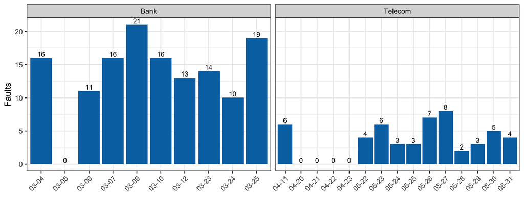

Figure 2: Injected faults per recorded day. Days are shown in order with gaps removed; days with no bar have telemetry but no recorded faults.

```r
per_day <- bind_rows(
  tibble(system = "Bank",    day = recorded_days("bank")),
  tibble(system = "Telecom", day = recorded_days("telecom"))) |>
  left_join(faults |> mutate(day = as.Date(onset, tz = "Asia/Shanghai")) |>
              count(system, day, name = "faults"), by = c("system", "day")) |>
  mutate(faults = replace_na(faults, 0L), label = format(day, "%m-%d"))

ggplot(per_day, aes(label, faults)) +
  geom_col(fill = "#0072B2") +
  geom_text(aes(label = faults), vjust = -0.3, size = 3) +
  facet_wrap(~system, scales = "free_x") +
  labs(x = NULL, y = "Faults") +
  theme_bw() + theme(axis.text.x = element_text(angle = 45, hjust = 1))
```

Faults are spread fairly evenly over the Bank days (10 to 21 a day), apart from 2021-03-05, which has full telemetry but no faults. Telecom is uneven: one fault-heavy day in April, four fault-free days in a row (04-20 to 04-23), and then 2 to 8 faults a day in late May. Because faults are injected about once an hour in both systems, a 60-minute look-back window before one fault often contains the aftermath of the previous one.

#### How complete the telemetry is

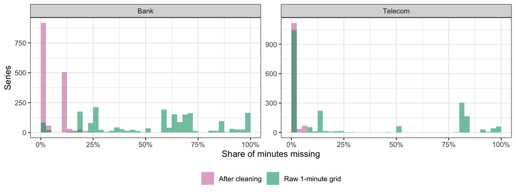

Figure 3: Share of missing minutes per series, on the raw 1-minute grid and after cleaning (series kept for the chronological split, after forward-filling).

```r
bind_rows(Bank = eda("bank", "missingness.csv"),
          Telecom = eda("telecom", "missingness.csv"), .id = "system") |>
  pivot_longer(c(raw, after_cleaning), names_to = "stage", values_to = "missing") |>
  filter(!is.na(missing)) |>
  mutate(stage = recode(stage, raw = "Raw 1-minute grid",
                        after_cleaning = "After cleaning")) |>
  ggplot(aes(missing, fill = stage)) +
  geom_histogram(binwidth = 0.025, position = "identity", alpha = 0.6, boundary = 0) +
  facet_wrap(~system, scales = "free_y") +
  scale_x_continuous(labels = scales::percent) +
  scale_fill_manual(values = c("Raw 1-minute grid" = "#009E73", "After cleaning" = "#CC79A7")) +
  labs(x = "Share of minutes missing", y = "Series", fill = NULL) +
  theme_bw() + theme(legend.position = "bottom")
```

On the raw 1-minute grid most Bank series are 20 % to 70 % missing. This is a sampling effect, not data loss: many Bank KPIs are recorded every 2 minutes or once an hour. Telecom series are either almost complete or mostly empty. After cleaning, the kept series are nearly complete (Bank 4.9 %, Telecom 1.4 % of cells still missing), so the LSTM sees a regular grid as the Methods section assumes.

#### What the telemetry looks like around a fault

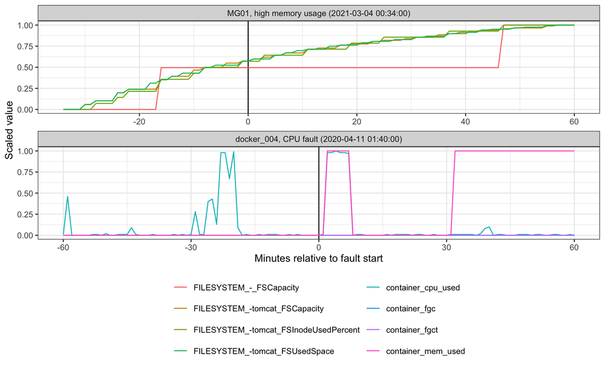

Figure 4: Four KPIs of the faulty component around one fault in each system, scaled to 0 to 1 over the window shown. The vertical line is the recorded fault start.

```r
bind_rows(eda("bank", "closeup.csv"), eda("telecom", "closeup.csv")) |>
  mutate(panel = paste0(component, ", ", reason, " (", onset, ")"),
         kpi = str_remove(kpi, "^OSLinux-OSLinux_|^container\\.")) |>
  ggplot(aes(minute, value, colour = kpi)) +
  geom_vline(xintercept = 0) +
  geom_line() +
  facet_wrap(~panel, ncol = 1, scales = "free_x") +
  labs(x = "Minutes relative to fault start", y = "Scaled value", colour = NULL) +
  theme_bw() + theme(legend.position = "bottom") +
  guides(colour = guide_legend(ncol = 2))
```

The two close-ups show why single examples are hard to read. On Bank server `MG01`, filesystem metrics grow steadily through the 30 minutes before a “high memory usage” fault, which at first looks like a warning sign. But they keep growing at the same pace for the hour after it, so the growth is more likely a steady trend, such as a disk filling up, than a sign of this fault. The memory metrics themselves do not move, so the label describes what was injected, not where it shows up. On Telecom container `docker_004`, CPU and memory use jump about two minutes after the recorded fault start and stay high for about six minutes. A similar CPU burst about 20 minutes earlier returns to normal without a fault, so it is unclear whether such bursts are warnings or noise.

#### Does the telemetry change before faults in general?

To look beyond single examples, we measured how much the telemetry moves around every fault. For each fault with at least 60 minutes of history on the same day, each feature is compared with its own median 31 to 60 minutes before the fault, in units of its training IQR, and the absolute change is averaged over all features. The same is done at 200 to 300 randomly chosen times at least 90 minutes away from any fault. This gives 126 fault windows for Bank and 40 for Telecom.

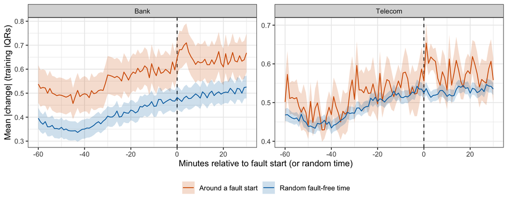

Figure 5: Average change in the telemetry relative to a baseline 31 to 60 minutes earlier, around fault starts and around random fault-free times. Ribbons are 95 % confidence intervals across windows.

```r
bind_rows(Bank = eda("bank", "onset_profile.csv"),
          Telecom = eda("telecom", "onset_profile.csv"), .id = "system") |>
  mutate(kind = recode(kind, fault = "Around a fault start",
                       random = "Random fault-free time")) |>
  group_by(system, kind, minute) |>
  summarise(mean = mean(change), se = sd(change) / sqrt(n()), .groups = "drop") |>
  ggplot(aes(minute, mean, colour = kind, fill = kind)) +
  geom_vline(xintercept = 0, linetype = "dashed") +
  geom_ribbon(aes(ymin = mean - 1.96 * se, ymax = mean + 1.96 * se),
              alpha = 0.2, colour = NA) +
  geom_line() +
  facet_wrap(~system, scales = "free_y") +
  scale_colour_manual(values = c("#D55E00", "#0072B2")) +
  scale_fill_manual(values = c("#D55E00", "#0072B2")) +
  labs(x = "Minutes relative to fault start (or random time)",
       y = "Mean |change| (training IQRs)", colour = NULL, fill = NULL) +
  theme_bw() + theme(legend.position = "bottom")
```

```r
bind_rows(Bank = eda("bank", "onset_profile.csv"),
          Telecom = eda("telecom", "onset_profile.csv"), .id = "System") |>
  filter(kind == "fault") |>
  mutate(period = case_when(minute < -30 ~ "base",
                            minute < 0 ~ "pre",
                            minute <= 5 ~ "onset",
                            TRUE ~ "later")) |>
  group_by(System, reason, period) |>
  summarise(change = mean(change), n = n_distinct(onset), .groups = "drop") |>
  pivot_wider(names_from = period, values_from = change) |>
  transmute(System, `Fault type` = reason, Faults = n,
            `Last 30 min before start` = sprintf("%+.3f", pre - base),
            `First 5 min after start` = sprintf("%+.3f", onset - base)) |>
  arrange(System, desc(Faults)) |>
  kable(caption = "Average telemetry change by fault type, relative to 31 to 60 minutes before the fault (training IQRs).")
```

Average telemetry change by fault type, relative to 31 to 60 minutes before the fault (training IQRs).

| System | Fault type | Faults | Last 30 min before start | First 5 min after start |
| --- | --- | --- | --- | --- |
| Bank | high CPU usage | 31 | +0.079 | +0.193 |
| Bank | network packet loss | 30 | +0.112 | +0.202 |
| Bank | network latency | 24 | +0.059 | +0.140 |
| Bank | high disk I/O read usage | 18 | +0.072 | +0.216 |
| Bank | high memory usage | 8 | +0.071 | +0.097 |
| Bank | JVM Out of Memory (OOM) Heap | 7 | +0.083 | +0.205 |
| Bank | high disk space usage | 5 | +0.164 | +0.193 |
| Bank | high JVM CPU load | 3 | +0.039 | +0.099 |
| Telecom | CPU fault | 15 | +0.067 | +0.124 |
| Telecom | network delay | 10 | +0.049 | +0.174 |
| Telecom | db connection limit | 6 | +0.078 | +0.121 |
| Telecom | network loss | 6 | +0.045 | +0.089 |
| Telecom | db close | 3 | -0.028 | -0.010 |

Figure 5 shows the central fact about these data. In both systems the telemetry around faults is somewhat busier than at quiet times throughout the hour (faults are injected about once an hour, so earlier faults are still settling), but the gap between the two curves **does not grow in the minutes before a fault**. It widens only at the fault start: in Bank the average change rises from about 0.60 in the last minutes before the start to about 0.68 in the first minutes after it, and in Telecom from about 0.55 to about 0.62, while the random-time curves only drift up slowly as the distance from their baseline grows.

The table breaks this down by fault type. Every type with more than three faults changes the telemetry more in the first 5 minutes after its start than in the 30 minutes before it. The fault types with the largest pre-onset change are Bank’s “high disk space usage” and “network packet loss”, but even there the change in the 30 minutes before the start is smaller than in the 5 minutes after it.

#### Unexpected patterns

- **Fault-free days.** Bank 2021-03-05 and Telecom 2020-04-20 to 04-23 have complete telemetry but no recorded faults. They may be quiet periods or gaps in the fault record; the dataset does not say which. Either way, they make some days look very different from others in their share of positive minutes.
- **Slow trends across days.** Some metrics, such as disk usage on the Bank `IG` servers, grow steadily over the recording. Such a metric separates early days from late days, and therefore days with few faults from days with many, without saying anything about the minutes before a particular fault.
- **Labels describe the injection, not the symptom.** The “high memory usage” fault in Figure 4 does not show up in the memory metrics of the faulty server, which argues for a model that can use all features rather than a hand-picked few.
- **Telecom covers only 00:00 to 05:59.** Every Telecom minute is in the early morning, so its daily load pattern differs from Bank’s 24-hour days.

These observations set expectations for the model: if the telemetry rarely changes before a fault, an LSTM, however good at remembering the past, has little to work with, and slow day-level trends may be the strongest signal available to it.

### Modeling and Results

We apply the same model and the same procedure to both systems. Bank is analysed first because it has the most fault events (136) and full 24-hour days; Telecom (51 events, 6 hours a day) then shows whether the findings carry over to a different system.

The LSTM is trained in Python with PyTorch. The scripts are in the `code/` folder of this repository and their outputs in `results/<system>/`; the report reads the saved results, so rendering it does not retrain the model.

```r
res <- function(system, run, file)
  read_csv(file.path("results", system, run, file), show_col_types = FALSE)
pct <- function(x, d = 1) scales::percent(x, accuracy = 10^-d)

show_metrics <- function(system, run) {
  alarmed <- res(system, run, "predictions.csv") |>
    group_by(horizon) |> summarise(alarmed = mean(alarm))
  res(system, run, "metrics.csv") |>
    left_join(alarmed, by = "horizon") |>
    transmute(`H (min)` = horizon,
              `Base rate` = round(base_rate, 3),
              `PR-AUC [95 % CI]` = sprintf("%.3f [%.3f, %.3f]", pr_auc, pr_auc_lo, pr_auc_hi),
              Lift = sprintf("%.2f", pr_lift),
              `ROC-AUC` = round(roc_auc, 3),
              `Minutes alarmed` = pct(alarmed),
              `Faults caught` = sprintf("%d / %d", events_detected, n_events),
              `False alarms / day` = round(false_alarms_per_day, 1))
}

plot_history <- function(system) {
  res(system, "chrono-level", "history.csv") |>
    mutate(H = factor(paste0("H = ", horizon),
                      levels = paste0("H = ", c(1, 3, 5, 10, 15, 30)))) |>
    pivot_longer(c(train_loss, val_pr_auc), names_to = "metric") |>
    mutate(metric = recode(metric, train_loss = "Training loss",
                           val_pr_auc = "Validation PR-AUC")) |>
    ggplot(aes(epoch, value, colour = H)) +
    geom_line() +
    geom_point(data = \(d) filter(d, epoch == best_epoch & metric == "Validation PR-AUC")) +
    facet_wrap(~metric, scales = "free_y") +
    labs(x = "Epoch", y = NULL, colour = NULL) +
    theme_bw()
}

plot_timeline <- function(system, sys_name, test_start, h = 5) {
  pred <- res(system, "chrono-level", "predictions.csv") |> filter(horizon == h) |>
    mutate(time = as.POSIXct(timestamp, origin = "1970-01-01", tz = "Asia/Shanghai"),
           day  = format(time, "%m-%d"))
  thr <- res(system, "chrono-level", "metrics.csv") |> filter(horizon == h) |> pull(threshold)
  onsets <- faults |>
    filter(system == sys_name,
           as.Date(onset, tz = "Asia/Shanghai") >= as.Date(test_start)) |>
    mutate(day = format(onset, "%m-%d"))
  ggplot(pred, aes(time, score)) +
    geom_vline(data = onsets, aes(xintercept = onset), colour = "#D55E00", alpha = 0.5) +
    geom_line(colour = "#0072B2", linewidth = 0.3) +
    geom_hline(yintercept = thr, linetype = "dashed") +
    facet_wrap(~day, scales = "free_x", nrow = 1) +
    scale_x_datetime(date_labels = "%H:%M") +
    labs(x = "Time (UTC+8)", y = "Predicted probability") +
    theme_bw()
}

plot_drift <- function(system, strip) {
  drift <- read_csv(file.path("results", system, "drift.csv"), show_col_types = FALSE) |>
    mutate(feature = str_replace(feature, strip, ": "),
           label = format(as.Date(day), "%m-%d"),
           x = as.integer(factor(label)))
  days <- distinct(drift, x, label, split)
  ggplot(drift, aes(x, scaled_mean, colour = feature)) +
    geom_rect(data = days,
              aes(xmin = x - 0.5, xmax = x + 0.5, ymin = -Inf, ymax = Inf, fill = split),
              inherit.aes = FALSE, alpha = 0.15) +
    geom_line() + geom_point() +
    scale_x_continuous(breaks = days$x, labels = days$label) +
    scale_fill_manual(values = c(train = "grey60", val = "#E69F00", test = "#D55E00")) +
    labs(x = "Day (recorded days only)", y = "Daily mean (training IQRs)",
         colour = NULL, fill = "Split") +
    theme_bw() +
    theme(legend.position = "bottom", legend.box = "vertical",
          axis.text.x = element_text(angle = 45, hjust = 1))
}

runs <- c("chrono-level"  = "Chronological, level",
          "chrono-change" = "Chronological, change",
          "cv-level"      = "Cross-validation, level",
          "cv-change"     = "Cross-validation, change")

plot_lift <- function(system) {
  imap_dfr(runs, \(lab, run) res(system, run, "metrics.csv") |> mutate(run = lab)) |>
    mutate(run = factor(run, levels = runs),
           lift_lo = pr_auc_lo / base_rate, lift_hi = pr_auc_hi / base_rate) |>
    ggplot(aes(factor(horizon), pr_lift, colour = run)) +
    geom_hline(yintercept = 1, linetype = "dashed") +
    geom_pointrange(aes(ymin = lift_lo, ymax = lift_hi),
                    position = position_dodge(width = 0.6)) +
    scale_y_log10() +
    scale_colour_manual(values = c("#0072B2", "#56B4E9", "#D55E00", "#E69F00")) +
    labs(x = "Horizon H (minutes)", y = "PR-AUC / base rate (log scale)", colour = NULL) +
    theme_bw() + theme(legend.position = "bottom")
}
```

#### Preprocessing for the model

The data are **split by day first**, and every step that learns anything from the data is then fitted on the training days only and applied unchanged to the validation and test days. This keeps the test period completely out of the model.

1. **Split by day.** Neighbouring minutes are almost identical, so a random split of minutes would put near-copies of the same moment in both training and test sets. We split by whole day and keep time order: the earliest days for training, the next day for validation, and the latest days (about 30 %) for testing. Bank uses 6 / 1 / 3 days and Telecom 10 / 1 / 4. The validation day is used for early stopping and for choosing the alarm threshold.
2. **Clean the telemetry** as described in Table 6: keep series observed on every training day, drop series mostly missing on training days, and fill gaps from past values only.
3. **Scale.** Each feature is centred on its training median and divided by its training interquartile range (IQR), then clipped to $\pm 10$. KPIs are heavy-tailed, and the median and IQR are not pulled around by extreme values.
4. **Select features.** Of the cleaned features (1,567 for Bank, 1,231 for Telecom), we keep the $k = 128$ with the highest ANOVA $F$-statistic between positive and negative training minutes.
5. **Build windows.** Each usable minute $t$ becomes one $60 \times 128$ input: the 60 minutes of scaled telemetry ending at $t$.
6. **Balance the training set.** Every positive training window is kept and negatives are randomly subsampled to five per positive; the loss also gives positives a weight equal to the negative-to-positive ratio. The validation and test sets are not resampled, so they keep the real, rare positive rate.

Table 8: What each preprocessing step is fitted on.

| Step | Learned from | Applied to |
| --- | --- | --- |
| Series kept (observed on every day, ≤ 80 % missing) | training days | all days |
| Gap-fill limit per series; median for leftover gaps | training days | all days |
| Gap filling | past values in the same day only | all days |
| Scaling (median, IQR) | training days | all days |
| Feature selection (ANOVA $F$) | training days and their labels | all days |
| Negative subsampling, positive-class weight | training days | training only |
| Early stopping, alarm threshold | validation day | not applied to data |
| Test-day labels | not used | scoring only |

```r
bind_rows(Bank    = res("bank",    "chrono-level", "split.csv"),
          Telecom = res("telecom", "chrono-level", "split.csv"), .id = "System") |>
  filter(horizon == 5) |>
  mutate(Split = str_to_title(split),
         Days  = str_replace_all(days, "20(20|21)-", ""),
         `Positive share` = pct(positive / windows)) |>
  select(System, Split, Days, Windows = windows, Positive = positive,
         `Positive share`, `Tensor shape` = shape) |>
  kable(caption = "Data after preprocessing, chronological split, 5-minute horizon. The training set is balanced to 5 negatives per positive; validation and test keep the true rate.")
```

Data after preprocessing, chronological split, 5-minute horizon. The training set is balanced to 5 negatives per positive; validation and test keep the true rate.

| System | Split | Days | Windows | Positive | Positive share | Tensor shape |
| --- | --- | --- | --- | --- | --- | --- |
| Bank | Train | 03-04, 03-05, 03-06, 03-07, 03-09, 03-10 | 2280 | 380 | 16.7% | 2280 x 60 x 128 |
| Bank | Val | 03-12 | 1242 | 65 | 5.2% | 1242 x 60 x 128 |
| Bank | Test | 03-23, 03-24, 03-25 | 3692 | 197 | 5.3% | 3692 x 60 x 128 |
| Telecom | Train | 04-11, 04-20, 04-21, 04-22, 04-23, 05-22, 05-23, 05-24, 05-25, 05-26 | 720 | 120 | 16.7% | 720 x 60 x 128 |
| Telecom | Val | 05-27 | 225 | 30 | 13.3% | 225 x 60 x 128 |
| Telecom | Test | 05-28, 05-29, 05-30, 05-31 | 1052 | 60 | 5.7% | 1052 x 60 x 128 |

#### Evaluation

Because failures are rare, accuracy is not useful: a model that never raises an alarm is 95 % accurate at $H = 5$. We report:

- **PR-AUC** (area under the precision–recall curve). A model that guesses at random scores the **base rate**, the share of positive minutes, so we also report the **lift**, PR-AUC divided by the base rate. A lift of 1 means no skill. The 95 % interval comes from resampling 60-minute blocks of the test set; if it includes the base rate, the model cannot be distinguished from guessing.
- **ROC-AUC**, where 0.5 means no skill.
- **Faults caught**: the share of faults with at least one alarm in the $H$ minutes before they start.
- **False alarms per day**: separate bursts of alarms with no fault following them. A Telecom “day” is the 6 hours of recorded telemetry.

PR-AUC and ROC-AUC measure how well the model *ranks* minutes and need no threshold. To turn probabilities into alarms, the threshold is set on the validation day so that the model would alarm on about 2 % of minutes (30 alarm-minutes per 24 hours). We also report the share of test minutes that actually cross this threshold. If it is far from 2 %, the model’s scores have shifted between the validation and test days, and the fault and false-alarm counts mostly reflect that shift rather than skill.

#### Bank

##### Training

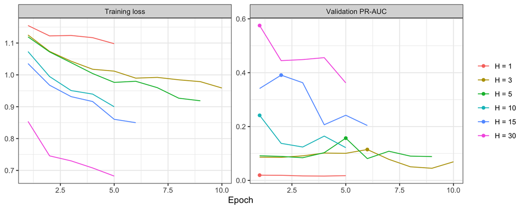

Figure 6: Training loss and validation PR-AUC by epoch for each horizon (Bank, chronological split). The dot marks the epoch whose weights were kept.

```r
plot_history("bank")
```

Training is fast: the balanced training set has only a few thousand windows, and each horizon finishes in a few seconds. Training loss falls steadily, but validation PR-AUC peaks early, between epochs 1 and 6, so early stopping ends every run within 10 epochs (Figure 6). On the validation day the model does find some signal: at $H = 10$ its best validation PR-AUC is 0.24 against a base rate of 0.10, and at $H = 30$ it is 0.58 against 0.28.

##### Results on the test days

```r
show_metrics("bank", "chrono-level") |>
  kable(caption = "LSTM on the Bank test days (2021-03-23 to 03-25), chronological split.")
```

LSTM on the Bank test days (2021-03-23 to 03-25), chronological split.

| H (min) | Base rate | PR-AUC [95 % CI] | Lift | ROC-AUC | Minutes alarmed | Faults caught | False alarms / day |
| --- | --- | --- | --- | --- | --- | --- | --- |
| 1 | 0.011 | 0.009 [0.006, 0.013] | 0.86 | 0.446 | 0.0% | 0 / 43 | 0 |
| 3 | 0.032 | 0.085 [0.029, 0.204] | 2.62 | 0.561 | 0.0% | 0 / 43 | 0 |
| 5 | 0.053 | 0.064 [0.039, 0.094] | 1.19 | 0.548 | 0.0% | 0 / 43 | 0 |
| 10 | 0.106 | 0.156 [0.103, 0.225] | 1.47 | 0.627 | 0.0% | 0 / 43 | 0 |
| 15 | 0.158 | 0.209 [0.134, 0.305] | 1.32 | 0.602 | 0.0% | 0 / 43 | 0 |
| 30 | 0.296 | 0.291 [0.197, 0.413] | 0.99 | 0.466 | 0.0% | 0 / 43 | 0 |

On the three test days the LSTM ranks minutes **slightly better than chance at the middle horizons, but not reliably**. At $H = 3$ to $15$ PR-AUC is above the base rate (lift 1.2–2.6) and ROC-AUC reaches 0.55–0.63, but every 95 % interval still includes the base rate. At $H = 1$ and $H = 30$ there is no skill at all.

The model also **raises no alarms**: on every horizon, the test scores stay below the threshold chosen on the validation day, so none of the 43 test faults is flagged.

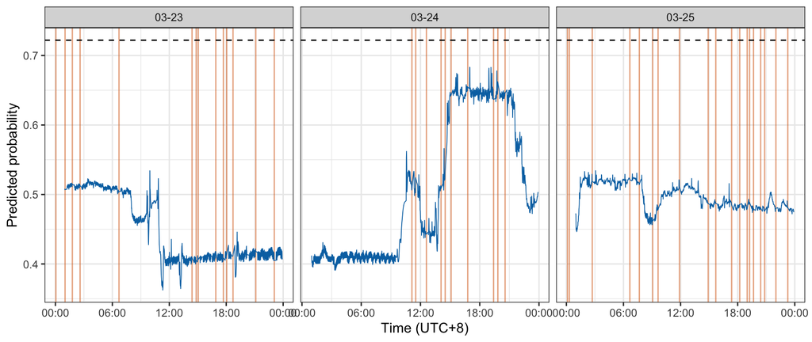

Figure 7: Predicted failure probability on the three Bank test days at H = 5. Red lines mark fault onsets; the dashed line is the alarm threshold chosen on the validation day.

```r
plot_timeline("bank", "Bank", "2021-03-23")
```

Figure 7 shows why. The predicted probability moves in slow waves over hours rather than rising in the minutes before each fault, and the whole curve sits lower than on the validation day.

##### What the model is picking up

The features ranked highest by the $F$-test are disk metrics on the two `IG` servers (used, available and total space) and connection counts on `Mysql01`. Figure 8 shows the daily level of the top four.

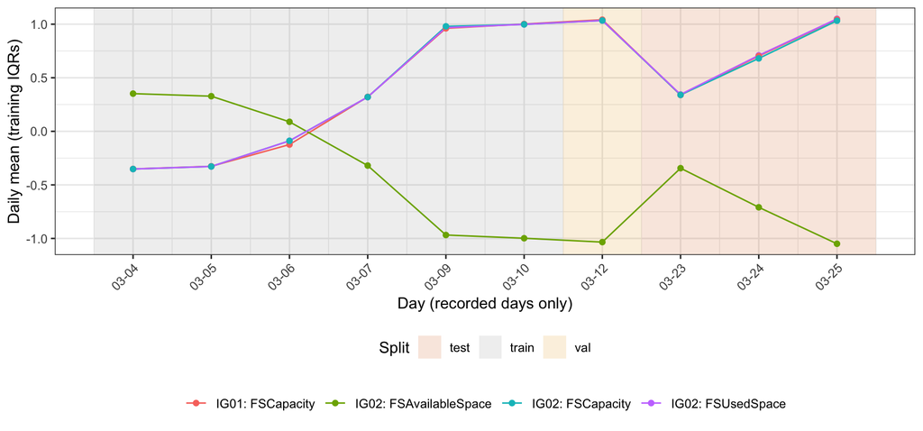

Figure 8: Daily mean of the four top-ranked Bank features, in units of training IQR from the training median. Shading shows the split each day belongs to.

```r
plot_drift("bank", "\\|\\|OSLinux-OSLinux_FILESYSTEM_-tomcat_")
```

Used disk space grows steadily across the training days, and the share of positive minutes also differs from day to day: 0 % on the fault-free 03-05 and up to 9 % on 03-09. A slowly drifting feature can therefore look predictive just because it tells the days apart. Within a single day, used disk space on `IG02` is only about a quarter of a standard deviation higher before faults than at other times. The $F$-test ranks these features highly, and the LSTM learns them, mostly because of differences *between* days rather than warning signs *before* each fault.

The test days stay inside the training range for these features, but the mix of inputs still shifts: 2.9 % of scaled test values are clipped at $\pm 10$, against 0.5 % on the training days. That is enough to move the model’s scores below the validation threshold.

##### Checking the explanation

Two further experiments test whether the signal comes from day-level differences:

- **Cross-validation.** Each pair of consecutive days is held out once as the test set (5 folds), so training always includes days from both ends of March. All cleaning, scaling and feature selection are re-fitted inside each fold, and the out-of-fold predictions are pooled before scoring. Because some training days come *after* the test days, this is a diagnostic, not a realistic forecast.
- **Change inputs.** Each window has its own median subtracted, feature by feature, so the model sees only how the metrics change within the hour and not their level. Features are also ranked on within-day variation, which removes day-to-day drift from the selection.

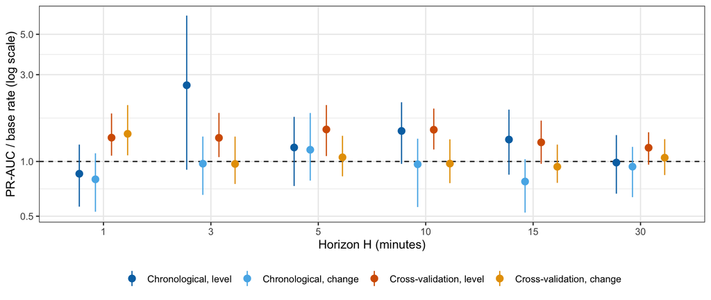

Figure 9: Bank: PR-AUC lift over the base rate with 95 % intervals, for both splits and both input types. A lift of 1 (dashed line) means no skill.

```r
plot_lift("bank")
```

```r
show_metrics("bank", "cv-level") |>
  kable(caption = "Bank with cross-validation (5 folds, all 10 days tested once), level inputs.")
```

Bank with cross-validation (5 folds, all 10 days tested once), level inputs.

| H (min) | Base rate | PR-AUC [95 % CI] | Lift | ROC-AUC | Minutes alarmed | Faults caught | False alarms / day |
| --- | --- | --- | --- | --- | --- | --- | --- |
| 1 | 0.010 | 0.014 [0.011, 0.019] | 1.35 | 0.573 | 14.2% | 28 / 136 | 25.4 |
| 3 | 0.031 | 0.042 [0.033, 0.058] | 1.35 | 0.581 | 23.7% | 45 / 136 | 15.1 |
| 5 | 0.052 | 0.078 [0.056, 0.106] | 1.50 | 0.588 | 16.4% | 36 / 136 | 12.0 |
| 10 | 0.103 | 0.155 [0.120, 0.202] | 1.49 | 0.602 | 16.4% | 44 / 136 | 14.6 |
| 15 | 0.154 | 0.196 [0.149, 0.258] | 1.27 | 0.552 | 15.7% | 35 / 136 | 14.0 |
| 30 | 0.287 | 0.341 [0.275, 0.415] | 1.19 | 0.558 | 11.7% | 32 / 136 | 8.7 |

The results support the explanation (Figure 9):

- With **cross-validation and level inputs**, the LSTM is consistently above chance: lift 1.2–1.5 at every horizon, ROC-AUC 0.55–0.60, and at four of the six horizons the interval excludes the base rate.
- With **change inputs**, which remove the day-level information, this advantage disappears: lift is 0.94–1.05 at every horizon from 3 to 30 minutes.
- With the **chronological split**, neither input type gives a reliable signal.

The fault counts in the cross-validation table look better (21–33 % of faults caught), but the thresholds there alarm on 12–24 % of minutes instead of 2 %; except at $H = 1$, random alarms at that rate would catch as many faults or more.

##### What the Bank data reveal

For Bank, the LSTM **does not find reliable warning signs in the hour before an injected fault**. The little skill it shows comes from slow differences between days, such as disk usage that grows over the recording. That information helps when training and test days are mixed, but not when the model has to predict later days from earlier ones, which is how it would be used in practice.

#### Telecom

Telecom is a harder setting: 15 six-hour days, 51 faults instead of 136, and three times as many components. The chronological split trains on 10 days (04-11, 04-20 to 04-23 and 05-22 to 05-26, with 29 faults), validates on 05-27 (8 faults) and tests on 05-28 to 05-31 (14 faults). Four of the training days have no faults at all.

##### Training

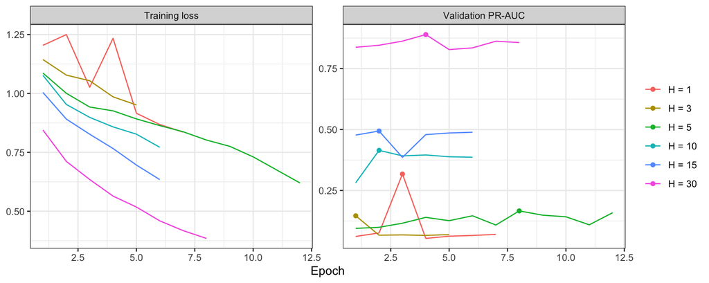

Figure 10: Training loss and validation PR-AUC by epoch for each horizon (Telecom, chronological split).

```r
plot_history("telecom")
```

As with Bank, validation PR-AUC peaks within the first few epochs (between epochs 1 and 8) and early stopping ends every run within 12 epochs. The validation day is unusually fault-heavy (13 % of minutes positive at $H = 5$), so validation PR-AUC looks high; relative to its base rate the gain is modest, for example 0.41 against 0.27 at $H = 10$.

##### Results on the test days

```r
show_metrics("telecom", "chrono-level") |>
  kable(caption = "LSTM on the Telecom test days (2020-05-28 to 05-31), chronological split. A day is 6 hours of telemetry.")
```

LSTM on the Telecom test days (2020-05-28 to 05-31), chronological split. A day is 6 hours of telemetry.

| H (min) | Base rate | PR-AUC [95 % CI] | Lift | ROC-AUC | Minutes alarmed | Faults caught | False alarms / day |
| --- | --- | --- | --- | --- | --- | --- | --- |
| 1 | 0.011 | 0.014 [0.008, 0.032] | 1.21 | 0.537 | 5.4% | 0 / 14 | 8.8 |
| 3 | 0.034 | 0.034 [0.018, 0.095] | 1.01 | 0.469 | 53.3% | 7 / 14 | 14.5 |
| 5 | 0.057 | 0.063 [0.034, 0.113] | 1.10 | 0.515 | 63.4% | 8 / 14 | 8.0 |
| 10 | 0.116 | 0.123 [0.055, 0.333] | 1.06 | 0.464 | 76.1% | 8 / 14 | 2.8 |
| 15 | 0.178 | 0.227 [0.093, 0.399] | 1.27 | 0.512 | 62.0% | 8 / 14 | 6.8 |
| 30 | 0.357 | 0.423 [0.235, 0.670] | 1.18 | 0.521 | 24.3% | 3 / 14 | 1.0 |

On the Telecom test days the LSTM is **no better than chance** at any horizon: lift is 1.0–1.3, ROC-AUC stays between 0.46 and 0.54, and every interval includes the base rate. With only 14 test faults, the intervals are also much wider than for Bank.

The alarms fail in the opposite way to Bank. The validation threshold is *too low* for the test days, so the model alarms on 53–76 % of test minutes at $H = 3$ to $15$ instead of about 2 %. It catches 7–8 of the 14 faults, but only because it is alarming most of the time.

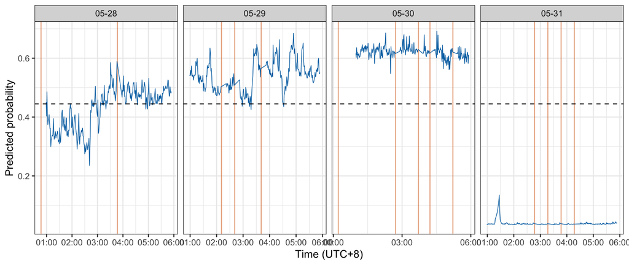

Figure 11: Predicted failure probability on the four Telecom test days at H = 5 (00:00–05:59 each day). Red lines mark fault onsets; the dashed line is the alarm threshold chosen on the validation day.

```r
plot_timeline("telecom", "Telecom", "2020-05-28")
```

##### What the model is picking up

The top-ranked Telecom features are memory metrics of host `os_021` (used and available memory, in absolute and percentage terms), followed by session and memory metrics of database `db_002` and host `os_019`.

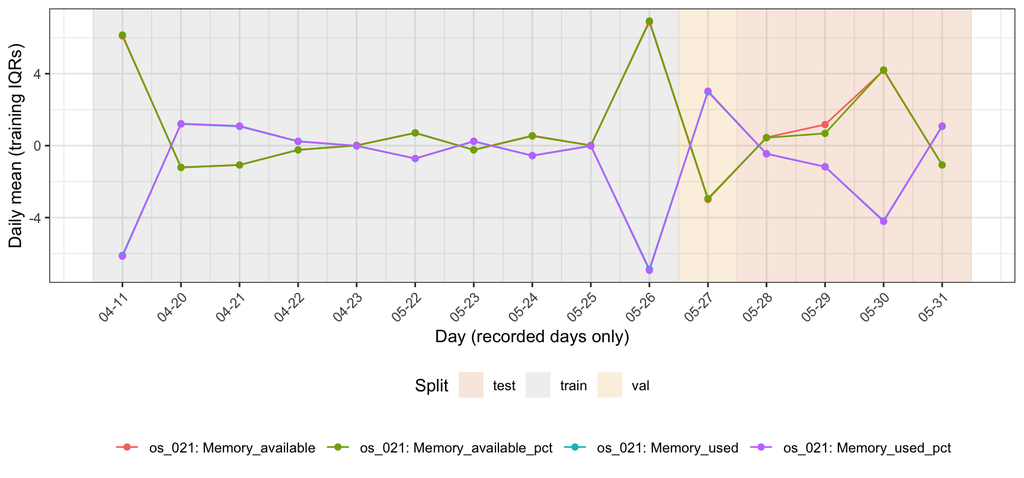

Figure 12: Daily mean of the four top-ranked Telecom features (memory on host os_021), in units of training IQR from the training median.

```r
plot_drift("telecom", "\\|\\|node\\.")
```

Figure 12 shows the same pattern as Bank, in a stronger form. Memory use on `os_021` is far below normal on 04-11 and 05-26, which are the two training days with the most faults (10 % and 16 % of minutes positive), and at or slightly above normal on the four fault-free days. The $F$-test therefore ranks this feature at the top, although within a day it differs between pre-fault and other minutes by only about a tenth of a standard deviation. The validation day breaks the pattern: it is fault-heavy but has *high* memory use, and 13 % of its scaled values are clipped, against 3 % on the training and test days. A threshold chosen on such a day does not transfer.

##### Checking the explanation

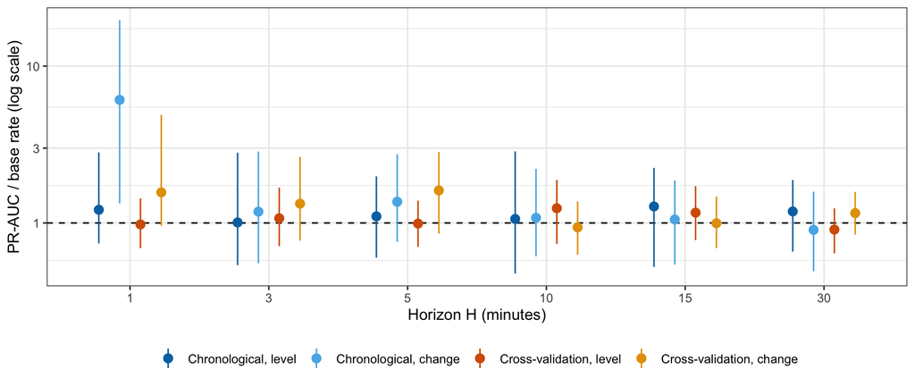

Figure 13: Telecom: PR-AUC lift over the base rate with 95 % intervals, for both splits and both input types.

```r
plot_lift("telecom")
```

Running the same two experiments (8 cross-validation folds) gives no consistent signal (Figure 13). With level inputs, cross-validation lift is 0.9–1.2; with change inputs it is 0.9–1.6, and every interval includes the base rate. The one exception is the chronological split with change inputs at $H = 1$ (lift 6.1, ROC-AUC 0.76, 3 of 14 faults caught). That result rests on 12 positive test minutes and concerns the single minute before the recorded start, where the fault may already be under way, so we treat it as a lead for future work rather than a finding.

##### What the Telecom data reveal

Telecom confirms the Bank result. The LSTM latches onto features that separate fault-heavy days from quiet ones, here memory use on one host, and this does not carry over to new days. With 51 faults in total and 14 in the test period, Telecom also shows how little data a fault-prediction study has once it is counted in events rather than minutes.

#### Studying the LSTM

The results so far describe what the model achieves. This part looks at *how* the LSTM behaves: whether it uses its memory, how sensitive it is to its settings, what its gates do, and which inputs drive its predictions. All experiments use the chronological split, level inputs and a horizon of $H = 10$ minutes, a middle horizon where about 10 % of minutes are positive in both systems. Each setting is trained once and scored on the validation day and on the test days.

```r
study <- function(system, file)
  read_csv(file.path("results", system, "study", file), show_col_types = FALSE)
both <- function(file)
  bind_rows(Bank = study("bank", file), Telecom = study("telecom", file), .id = "system")
```

##### Memory length and model size

The defining feature of an LSTM is its ability to remember. If warning signs built up over the hour before a fault, a longer look-back window should help. We varied the look-back from $L = 1$ minute, which gives the LSTM a single time step and so no sequence at all, up to $L = 120$ minutes. We also varied the number of hidden units from $d = 8$ to $d = 128$, which changes the number of parameters from about 4,400 to about 132,000.

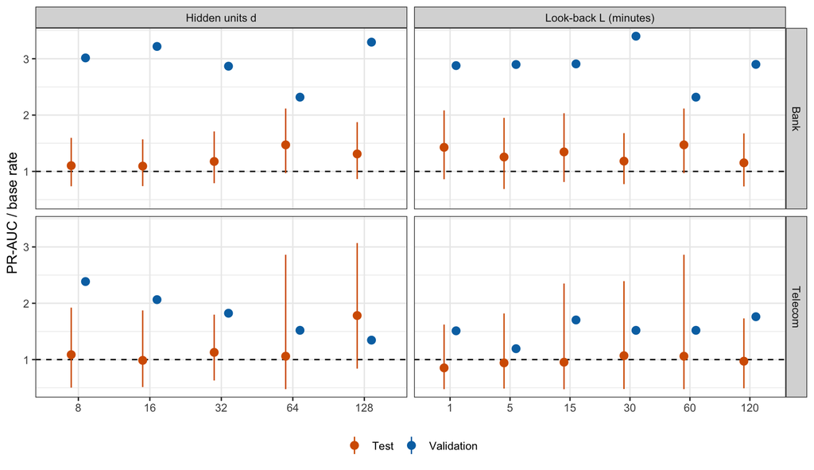

```r
bind_rows(both("lookback.csv") |> mutate(setting = "Look-back L (minutes)", value = lookback),
          both("hidden.csv")   |> mutate(setting = "Hidden units d",        value = hidden)) |>
  transmute(system, setting, value = factor(value),
            Validation = val_lift, Test = test_lift,
            lo = test_lo / test_base, hi = test_hi / test_base) |>
  pivot_longer(c(Validation, Test), names_to = "data", values_to = "lift") |>
  mutate(lo = if_else(data == "Test", lo, NA_real_),
         hi = if_else(data == "Test", hi, NA_real_)) |>
  ggplot(aes(value, lift, colour = data)) +
  geom_hline(yintercept = 1, linetype = "dashed") +
  geom_pointrange(aes(ymin = lo, ymax = hi), position = position_dodge(width = 0.4),
                  na.rm = TRUE) +
  geom_point(position = position_dodge(width = 0.4)) +
  facet_grid(system ~ setting, scales = "free_x") +
  scale_colour_manual(values = c(Test = "#D55E00", Validation = "#0072B2")) +
  labs(x = NULL, y = "PR-AUC / base rate", colour = NULL) +
  theme_bw() + theme(legend.position = "bottom")
```

**Validation scores do not predict test scores.** Every setting looks useful on the validation day (lift 2.3 to 3.4 on Bank, 1.2 to 2.4 on Telecom), yet test lift is much lower. Choosing the setting with the best validation score would have picked $L = 30$ for Bank (test lift 1.18) and $d = 8$ for Telecom (test lift 1.09), neither of which is the best on the test days. The validation day, one day just after training, is not representative of the later test days.

##### Stability across random seeds

```r
both("seeds.csv") |>
  group_by(System = system) |>
  summarise(Runs = n(),
            `Validation lift, mean (SD)` = sprintf("%.2f (%.2f)", mean(val_lift), sd(val_lift)),
            `Test lift, mean (SD)` = sprintf("%.2f (%.2f)", mean(test_lift), sd(test_lift)),
            `Test lift range` = sprintf("%.2f to %.2f", min(test_lift), max(test_lift)),
            `Test ROC-AUC range` = sprintf("%.2f to %.2f", min(test_roc), max(test_roc))) |>
  kable(caption = "The default LSTM (L = 60, d = 64) trained with five random seeds, H = 10.")
```

The default LSTM (L = 60, d = 64) trained with five random seeds, H = 10.

| System | Runs | Validation lift, mean (SD) | Test lift, mean (SD) | Test lift range | Test ROC-AUC range |
| --- | --- | --- | --- | --- | --- |
| Bank | 5 | 2.80 (0.43) | 1.23 (0.29) | 0.87 to 1.48 | 0.44 to 0.63 |
| Telecom | 5 | 1.65 (0.52) | 1.14 (0.13) | 1.01 to 1.34 | 0.46 to 0.51 |

Training the same model with five different random seeds changes the result as much as changing its settings. On Bank the test lift ranges from 0.87 to 1.48 (mean 1.23), so one seed is worse than random guessing and another is among the best runs of the whole study. On Telecom it ranges from 1.01 to 1.34 (mean 1.14). Any single run, including the results reported above, should be read with this spread in mind.

##### Inside the LSTM: the gates

Because the gate equations in Equation 3 are explicit, we can compute the gate values the trained model produces. Figure 15 shows the forget, input and output gates, averaged over all hidden units and over the test windows, at each minute of the 60-minute window. Windows before a fault and other windows are shown separately.

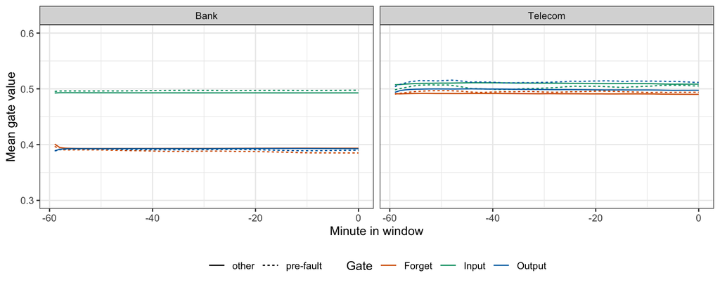

Figure 15: Mean gate activation at each minute of the look-back window (0 = the current minute), default model, test windows, H = 10.

```r
both("gates.csv") |>
  mutate(gate = str_to_title(gate)) |>
  ggplot(aes(minute, mean, colour = gate, linetype = label)) +
  geom_line() +
  facet_wrap(~system) +
  scale_colour_manual(values = c(Forget = "#D55E00", Input = "#009E73", Output = "#0072B2")) +
  coord_cartesian(ylim = c(0.3, 0.6)) +
  labs(x = "Minute in window", y = "Mean gate value", colour = "Gate", linetype = NULL) +
  theme_bw() + theme(legend.position = "bottom")
```

The gates explain why memory length does not matter. In Bank the forget gate averages about 0.39 at every minute. Because the cell state is multiplied by the forget gate at each step ($c_t = f_t \odot c_{t-1} + \dots$), information from $k$ minutes ago is scaled by roughly $0.39^k$: about 15 % survives two minutes and less than 1 % survives five. The trained Bank LSTM has learned to **forget almost immediately**, so in practice it acts on the last minute or two. In Telecom all three gates stay close to 0.5, which is the value of the sigmoid at zero: the network has barely moved away from its starting point before early stopping ends training, again consistent with there being little to learn. In both systems the gate values before faults and at other times are almost identical.

##### What the predictions depend on

To see which inputs drive the predictions, we computed the gradient of the model’s output with respect to every input value and multiplied it by that value (input × gradient). Large values mean that changing the input would change the prediction. Averaging over features gives the importance of each minute of the window (Figure 16); averaging over minutes gives the importance of each feature.

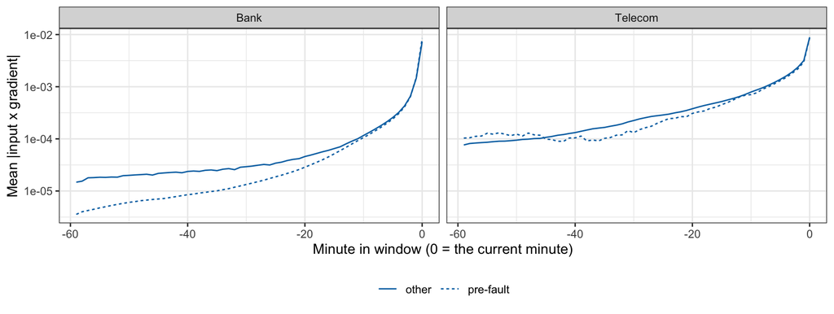

Figure 16: Mean |input × gradient| for each minute of the look-back window (log scale), default model, test windows, H = 10.

```r
both("saliency_time.csv") |>
  ggplot(aes(minute, saliency, linetype = label)) +
  geom_line(colour = "#0072B2") +
  scale_y_log10() +
  facet_wrap(~system) +
  labs(x = "Minute in window (0 = the current minute)", y = "Mean |input x gradient|",
       linetype = NULL) +
  theme_bw() + theme(legend.position = "bottom")
```

```r
both("saliency_feature.csv") |>
  group_by(system) |> slice_head(n = 8) |>
  mutate(Rank = row_number(),
         Component = str_extract(feature, "^[^|]+"),
         KPI = str_remove(feature, "^[^|]+\\|\\|") |>
           str_remove("^OSLinux-OSLinux_|^Mysql-MySQL_3306_|^redis-Redis_6379_")) |>
  ungroup() |>
  select(System = system, Rank, Component, KPI) |>
  kable(caption = "The eight features with the largest mean |input x gradient|, default model, H = 10.")
```

The eight features with the largest mean |input x gradient|, default model, H = 10.

| System | Rank | Component | KPI |
| --- | --- | --- | --- |
| Bank | 1 | Tomcat04 | ZABBIX_Host_Uptime |
| Bank | 2 | Tomcat02 | ZABBIX_Host_Uptime |
| Bank | 3 | Mysql02 | Binlog stmt cache use |
| Bank | 4 | Tomcat03 | ZABBIX_Host_Uptime |
| Bank | 5 | apache02 | FILESYSTEM_-apache_FSUsedSpace |
| Bank | 6 | Tomcat04 | FILESYSTEM_-home_FSInodeUsedPercent |
| Bank | 7 | Tomcat04 | FILESYSTEM_-home_FSUsedSpace |
| Bank | 8 | Tomcat02 | FILESYSTEM_-home_FSUsedSpace |
| Telecom | 1 | os_014 | node.Memory_used_pct |
| Telecom | 2 | redis_011 | middleware.Redis_key_count |
| Telecom | 3 | os_014 | node.Memory_used |
| Telecom | 4 | redis_007 | middleware.Redis_key_count |
| Telecom | 5 | redis_002 | middleware.Redis_key_count |
| Telecom | 6 | redis_010 | middleware.used_memory_rss |
| Telecom | 7 | os_013 | node.Memory_available_pct |
| Telecom | 8 | db_002 | service.Proc_Used_Pct |

##### What the LSTM study shows

The LSTM’s defining strength, a long memory controlled by learned gates, goes unused on these data. Trained on OpenRCA telemetry, it learns to forget within a minute or two, relies on the current readings, and leans on features that track elapsed time. This is a sensible response to the data rather than a failure of training: as Figure 5 showed, the telemetry does not change before faults, so there is no long-range pattern for the memory to hold.

#### Comparing the two systems

```r
bind_rows(Bank    = res("bank",    "chrono-level", "metrics.csv"),
          Telecom = res("telecom", "chrono-level", "metrics.csv"), .id = "System") |>
  group_by(System) |>
  summarise(`Lift range` = sprintf("%.2f to %.2f", min(pr_lift), max(pr_lift)),
            `ROC-AUC range` = sprintf("%.2f to %.2f", min(roc_auc), max(roc_auc)),
            `Horizons with CI above base rate` =
              sprintf("%d of %d", sum(pr_auc_lo > base_rate), n()),
            `Test faults` = first(n_events)) |>
  kable(caption = "Chronological split, level inputs: summary over the six horizons.")
```

Chronological split, level inputs: summary over the six horizons.

| System | Lift range | ROC-AUC range | Horizons with CI above base rate | Test faults |
| --- | --- | --- | --- | --- |
| Bank | 0.86 to 2.62 | 0.45 to 0.63 | 0 of 6 | 43 |
| Telecom | 1.01 to 1.27 | 0.46 to 0.54 | 0 of 6 | 14 |

Across two systems with different domains, components and fault types, the picture is the same: on later days the LSTM ranks minutes no better than chance, its scores shift between days so that a fixed alarm threshold either never fires (Bank) or fires most of the time (Telecom), and the features it relies on mainly tell days apart.

### Conclusion

**Key findings.**

- An LSTM given the last 60 minutes of metric telemetry **did not reliably predict injected failures** in either OpenRCA system when tested on later days. Across horizons from 1 to 30 minutes, PR-AUC stayed within the uncertainty of the base rate for both Bank (43 test faults) and Telecom (14 test faults).
- The modest skill the model showed came from **differences between days** (disk usage growing over the Bank recording, memory use on one Telecom host) rather than warning signs in the minutes before a fault. When the inputs were reduced to within-hour changes, the skill disappeared.
- The model’s output **shifted from day to day**, so an alarm threshold tuned on one day never fired on the Bank test days and fired most of the time on the Telecom test days.
- The telemetry itself **changes at the start of a fault, not before it**. Averaged over all faults, the metrics move no more in the hour before a fault than at quiet times, and then jump in the first minutes after it.
- The LSTM’s memory **went unused**. A model that sees only the current minute did as well as one that sees the whole hour. In Bank the trained forget gate keeps less than 1 % of the cell state after five minutes and the last three minutes carry about three quarters of the input importance; in Telecom the gates barely moved from their starting values. The most influential inputs were counters and clocks such as host uptime, which encode elapsed time rather than system health.
- Results varied as much between **random seeds** as between settings, and the setting that looked best on the validation day was never the best on the test days.

**Implications.**

- For **choosing an LSTM**, its advantage depends on the data containing patterns that unfold over time. When warning signs do not exist, as in these injected-fault data, the gates learn to discard the past and the LSTM behaves like a model of the current minute, with extra parameters and extra variance from training.
- For **this kind of data**, minute-level early warning appears very hard. Many injected faults (CPU load, network loss, latency) are switched on abruptly, so the metrics may not change until the fault starts. Benchmarks such as OpenRCA, built for root-cause analysis, may be better suited to detecting and diagnosing failures than to predicting them.
- For **evaluating failure prediction**, the design choices matter as much as the model. Splitting by day, testing on later days, fitting all preprocessing on the training days, and counting results in fault events rather than minutes all made the results less flattering but more honest. A random split of minutes, or preprocessing fitted on all days, would overstate how well the model works.
- For **deploying** such a model, a fixed threshold is not enough: scores would need to be recalibrated regularly, for example against a rolling window of recent data.

## References

Bengio, Yoshua, Patrice Simard, and Paolo Frasconi. 1994. “Learning Long-Term Dependencies with Gradient Descent Is Difficult.” *IEEE Transactions on Neural Networks* 5 (2): 157–66. https://doi.org/10.1109/72.279181.

Chen, Yiyong, Nurbol Luktarhan, and Dan Lv. 2022. “LogLS: Research on System Log Anomaly Detection Method Based on Dual LSTM.” *Symmetry* 14 (3): 454. https://doi.org/10.3390/sym14030454.

Ergen, Tolga, and Suleyman Serdar Kozat. 2020. “Unsupervised Anomaly Detection with LSTM Neural Networks.” *IEEE Transactions on Neural Networks and Learning Systems* 31 (8): 3127–41. https://doi.org/10.1109/TNNLS.2019.2935975.

Gers, Felix A., Jürgen Schmidhuber, and Fred Cummins. 2000. “Learning to Forget: Continual Prediction with LSTM.” *Neural Computation* 12 (10): 2451–71. https://doi.org/10.1162/089976600300015015.

Gonzalez, Jesus, and Wen Yu. 2018. “Non-Linear System Modeling Using LSTM Neural Networks.” *IFAC-PapersOnLine* 51 (13): 485–89. https://www.sciencedirect.com/science/article/pii/S2405896318310814.

Hadadi, Fatemeh, Joshua H. Dawes, Donghwan Shin, Domenico Bianculli, and Lionel Briand. 2024. “Systematic Evaluation of Deep Learning Models for Log-Based Failure Prediction.” *Empirical Software Engineering* 29: 105. https://doi.org/10.1007/s10664-024-10501-4.

Hochreiter, Sepp, and Jürgen Schmidhuber. 1997. “Long Short-Term Memory.” *Neural Computation* 9 (8): 1735–80. https://doi.org/10.1162/neco.1997.9.8.1735.

Kingma, Diederik P., and Jimmy Ba. 2015. “Adam: A Method for Stochastic Optimization.” In *International Conference on Learning Representations (ICLR)*. https://arxiv.org/abs/1412.6980.

Mudgal, Priyanka, and Rita H. Wouhaybi. 2024. “Ensemble Method for System Failure Detection Using Large-Scale Telemetry Data.” https://arxiv.org/abs/2407.00048.

Pascanu, Razvan, Tomas Mikolov, and Yoshua Bengio. 2013. “On the Difficulty of Training Recurrent Neural Networks.” In *Proceedings of the 30th International Conference on Machine Learning (ICML)*, 28:1310–18. PMLR 3.

Paszke, Adam, Sam Gross, Francisco Massa, Adam Lerer, James Bradbury, Gregory Chanan, et al. 2019. “PyTorch: An Imperative Style, High-Performance Deep Learning Library.” In *Advances in Neural Information Processing Systems 32 (NeurIPS)*, 8024–35.

Srivastava, Nitish, Geoffrey Hinton, Alex Krizhevsky, Ilya Sutskever, and Ruslan Salakhutdinov. 2014. “Dropout: A Simple Way to Prevent Neural Networks from Overfitting.” *Journal of Machine Learning Research* 15 (56): 1929–58.

Werbos, Paul J. 1990. “Backpropagation Through Time: What It Does and How to Do It.” *Proceedings of the IEEE* 78 (10): 1550–60. https://doi.org/10.1109/5.58337.

Xu, Junjielong, Qinan Zhang, Zhiqing Zhong, Shilin He, Chaoyun Zhang, Qingwei Lin, Dan Pei, Pinjia He, Dongmei Zhang, and Qi Zhang. 2025a. “OpenRCA: Can Large Language Models Locate the Root Cause of Software Failures?” In *The Thirteenth International Conference on Learning Representations (ICLR)*. https://proceedings.iclr.cc/paper_files/paper/2025/hash/d29b8d53678015079e1d245c023e49d2-Abstract-Conference.html.

———. 2025b. “OpenRCA: Can Large Language Models Locate the Root Cause of Software Failures?” In *International Conference on Learning Representations*. https://openreview.net/forum?id=M4qNIzQYpd.